[figure not shown]

## Case Study: Book displays at Flourish and Blotts

#### Prepared by Cynthia Hayward

The manager of Flourish and Blotts bookstore is trying to decide the best ways to arrange the book displays for the upcoming summer season in order to increase sales. We have been given a large data set with 90,000+ historical sales transactions. Using frequency pattern analysis, we will answer the following questions:

1. What are the best-selling titles?
2. Which books should be included when creatng a book display to appeal to readers belonging to book clubs? Click the followng link to access the printable list of Oprah’s book club: (https://static.oprah.com/images/o2/201608/201608-obc-complete-list-01a.pdf).
3. We will recommend other books that he should include in other display cases.
4. The book entitled “Wild Animus” is an interesting publishing story. Literarily, it is not significant–but is evidence of what an ego and too much money can do. The link leads to an interesting blog entry on the book:

   https://litreactor.com/columns/what-the-hell-is-wild-animus

### Inspecting the Transaction Data

We will begin our study by inspecting the first five transaction records.

```
##     items                                                                                           transactionID
## [1] {New Vegetarian: Bold and Beautiful Recipes for Every Occasion}                                        10
## [2] {Il Dio Delle Piccole Cose}                                                                            1000
## [3] {Cybernation}                                                                                          100001
## [4] {Lasher: Lives of the Mayfair Witches}                                                                 100002
## [5] {Chicken Soup for the Teenage Soul on Tough Stuff : Stories of Tough Times and Lessons Learned,
##      Dragon Ball Z, Vol. 1,
##      Harry Potter and the Chamber of Secrets,
##      Harry Potter and the Sorcerer's Stone,
##      Holes,
##      Prey,
##      Primary Colors: A Novel of Politics,
##      Rising Sun,
##      The Cat Who Smelled a Rat,
##      The Fellowship of the Ring,
##      The Hunt for Red October,
##      The Return of the King,
##      The Two Towers}                                                                                       100004
```

Next, it will be helpful to calculate the number of books purchased by user: We’ll call them baskets. Interestingly, purchases for some users is quite high. One user has over 10,000 transactions! In order for our pattern analysis to have meaning, we will limit our basket sizes. To determine where to cut off, let’s plot the values to take a look.

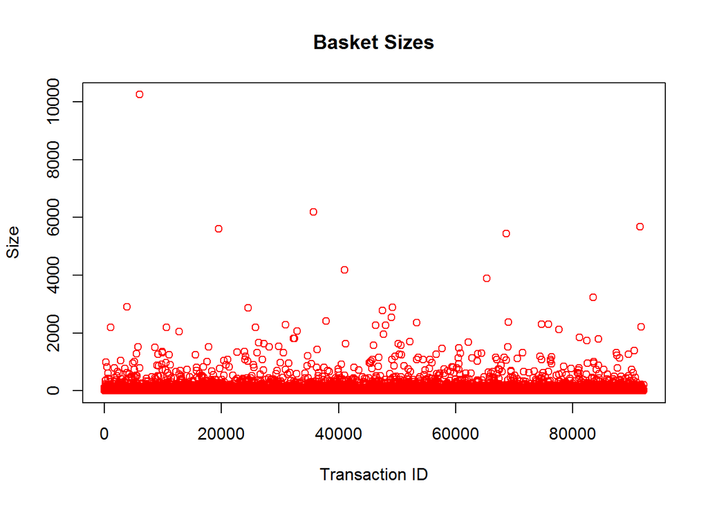

##### Basket Size

It appears that most of the baskets are around 500 or less. We will include baskets which have more than one book and less than 500 books.

### Which Books are Most Popular? Why is that book Wild Animus in the List?

One of our goals was to determine the books which have sold the most. Using all of the transaction data, we have determined the following books to be in our “Top Twenty” The manager mentioned that the book Wild Animus had a very strange story. We did the research, and it seemed that most books were given away. From our transaction data, Flourish and Blotts sold almost 2000 copies of Wild Animus. Very interesting revelation!

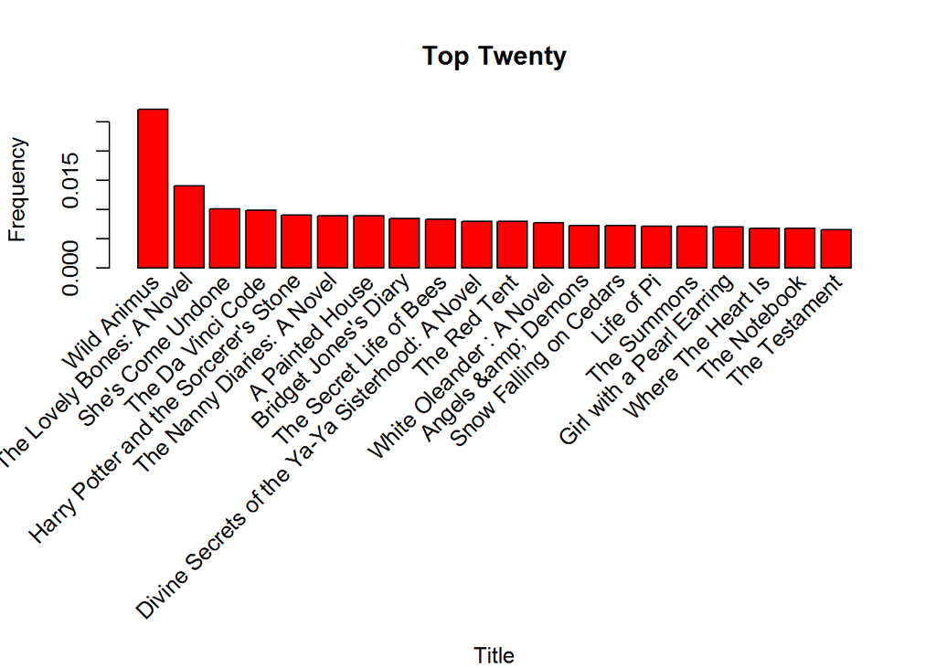

### Apriori Algorithm

The Apriori Algorithm is the most frequently used Frequency Pattern Analysis(FPA) algorithm.

The benefit is its scalability for large datasets. Unfortunately, it is computationally intensive.

**Data format requirement**: Horizontal. One column has the transaction ID). Another column has a list of items.

##### You may access the documentation for apriori() in the arules package.

## Book Club Recommendations using the Apriori Algorithm

Using Oprah’s Book Club list as a guide, we can surmise that book clubs read popular novels. If we look at the top selling novels from the bar chart above, we can use them to see what the buyers of those novels might likely purchase. The ten “rules” are displayed below in no particular order:

[output not shown]

[output not shown]

```
##      lhs                             rhs                                                    support confidence      lift
## [1]  {The Deep End of the Ocean,
##       The Red Tent,
##       Where The Heart Is}         => {Divine Secrets of the Ya-Ya Sisterhood: A Novel} 0.0001972192  0.8888889  62.59877
## [2]  {The Deep End of the Ocean,
##       The Lovely Bones: A Novel,
##       The Red Tent,
##       White Oleander : A Novel}   => {Divine Secrets of the Ya-Ya Sisterhood: A Novel} 0.0001972192  1.0000000  70.42361
## [3]  {The Lovely Bones: A Novel,
##       The Secret Life of Bees,
##       Where The Heart Is,
##       White Oleander : A Novel}   => {A Map of the World}                              0.0002465240  0.9090909 148.09785
## [4]  {House of Sand and Fog,
##       She's Come Undone,
##       The Lovely Bones: A Novel,
##       Where The Heart Is}         => {The Reader}                                      0.0001972192  0.8888889 103.91034
## [5]  {She's Come Undone,
##       The Lovely Bones: A Novel,
##       Where The Heart Is,
##       White Oleander : A Novel}   => {While I Was Gone}                                0.0002958288  0.9230769 119.62841
## [6]  {A Painted House,
##       The Lovely Bones: A Novel,
##       The Secret Life of Bees,
##       Where The Heart Is}         => {While I Was Gone}                                0.0001972192  0.8888889 115.19773
## [7]  {A Painted House,
##       House of Sand and Fog,
##       The Red Tent,
##       The Secret Life of Bees}    => {Girl with a Pearl Earring}                       0.0001972192  1.0000000  78.76505
## [8]  {A Painted House,
##       The Lovely Bones: A Novel,
##       The Nanny Diaries: A Novel,
##       Where The Heart Is}         => {The Street Lawyer}                               0.0002218716  0.9000000  89.47941
## [9]  {She's Come Undone,
##       The Lovely Bones: A Novel,
##       The Nanny Diaries: A Novel,
##       The Red Tent,
##       White Oleander : A Novel}   => {We Were the Mulvaneys}                           0.0001972192  0.8888889 138.14900
## [10] {She's Come Undone,
##       The Lovely Bones: A Novel,
##       The Red Tent,
##       Where The Heart Is,
##       White Oleander : A Novel}   => {While I Was Gone}                                0.0001972192  0.8888889 115.19773
```

##### According to our analysis, the manager should display the following books targeted to members of book clubs:

**A Map of the World**  
**We Were the Mulvaneys**  
**While I was Gone**  
**The Reader**  
**The Street Lawyer**  
**Girl with the Pearl Earring**  
**Divine Secrets of the Ya-Ya Sisterhood: A Novel**

### Confidence and Lift

Lift measures “how much more likely an item is to be purchased relative to its typical purchase rate, given that you know another item has been purchased” (Lantz 2013, p. 261).

### What Other Displays Should be Done?

**Best Sellers**  
We know these sell–so why not put them together? A selection could look like:

The Lovely Bones: A Novel  
She’s Come Undone  
The Nanny Diaries: A Novel  
A Painted House